# Milestone Report

Agatha North

# Employee Attrition

## An Under Recognized Problem

Workplace attrition is a universal factor in any form of employment. Attrition has many forms, both voluntary and involuntary, and its effects on a business can be felt both fiscally and within the workplace community. Because even valued employees are affected by attrition it is often viewed as a necessary evil in the workplace, something that is outside individual control.

Employee morale tends to be the biggest loss when attrition is concerned. After all, no one likes being fired, no one enjoys seeing their friends and co-workers being let go, and no one wants to train their friends’ replacement. At the same time, businesses don’t want their best workers leaving to seek opportunity elsewhere. Skilled workers can be considered a commodity like any other. The investment that goes into them; the hours of training, the workplace efficiency that familiarity helps foster, and the saved expenses on training, interviewing, and advertising, are all significant factors that companies need to consider. New hires mean risk where reliable and experienced employees can be considered stable.

Preventing unnecessary attrition in the workplace is an effective means of reducing expenses, and increasing employee engagement. Finding sustainable and realistic ways to increase employee satisfaction is something most companies can benefit and learn from.

## The Data

This analysis is possible due to 37 anonymous companies that used the company feedback app Happyforce (found at https://www.myhappyforce.com/en/). These companies provided their data for this set, which was then broken down into 4 dataframes. This includes churn data, employee comments, employee likes/dislikes, and self reported happiness votes. The dataset can be found at: https://www.kaggle.com/harriken/employeeturnover

## Data Wrangling

Cleaning this data was relatively simple. The data is straightforward in its purpose and format, so the chief concerns in cleaning it were to make the dataframes with the same variables match, to increase term clarity, and to simplify the dates.

My code:

```r
votes$voteDate <- gsub("CET","",votes$voteDate)
votes$voteDate <- gsub("CEST","",votes$voteDate)
votes$voteDate <- gsub("  "," ",votes$voteDate)
votes$voteDate <- parse_date_time(votes$voteDate, "%a %b %d %H:%M:%S %Y")

churn$lastParticipationDate <- gsub("CET","",churn$lastParticipationDate)
churn$lastParticipationDate <- gsub("CEST","",churn$lastParticipationDate)
churn$lastParticipationDate <- gsub("  "," ",churn$lastParticipationDate)
churn$lastParticipationDate <- parse_date_time(churn$lastParticipationDate, "%a %b %d %H:%M:%S %Y")

comments$commentDate <- gsub("CET","",comments$commentDate)
comments$commentDate <- gsub("CEST","",comments$commentDate)
comments$commentDate <- gsub("  "," ",comments$commentDate)
comments$commentDate <- parse_date_time(comments$commentDate, "%a %b %d %H:%M:%S %Y")

levels(votes$companyAlias) <- c("C1","C2","C3","C4","C5","C6","C7","C8","C9","C10","C11","C12","C13","C14","C15","C16","C17","C18","C19","C20","C21","C22","C23","C24","C25","C26","C27","C28","C29","C30","C31","C32","C33","C34","C35","C36","C37")
levels(churn$companyAlias) <- c("C1","C2","C3","C4","C5","C6","C7","C8","C9","C10","C11","C12","C13","C14","C15","C16","C17","C18","C19","C20","C21","C22","C23","C24","C25","C26","C27","C28","C29","C30","C31","C32","C33","C34","C35","C36","C37")
levels(comments$companyAlias) <- c("C1","C2","C3","C4","C5","C6","C7","C8","C9","C10","C11","C12","C13","C14","C15","C16","C17","C18","C19","C20","C21","C22","C23","C24","C25","C26","C27","C28","C29","C30","C31","C32","C33","C34","C35","C36")
levels(interaction$companyAlias) <- c("C1","C2","C3","C4","C5","C6","C7","C8","C9","C10","C11","C12","C13","C14","C15","C16","C17","C18","C19","C20","C21","C22","C23","C24","C25","C26","C27","C28","C29","C30","C31","C32","C33","C34","C35")

colnames(churn)[4] <- c("lastPostDate")

votes$EmpID <- paste0(votes$employee, votes$companyAlias)
comments$EmpID <- paste0(comments$employee, comments$companyAlias)
interaction$EmpID <- paste0(interaction$employee, interaction$companyAlias)
churn$EmpID <- paste0(churn$employee, churn$companyAlias)

comments$txt <- as.character(comments$txt)
comments$LengthTxt <- nchar(comments$txt)

EmpVoteCount <- votes%>%group_by(EmpID)%>%dplyr::summarize(VoteCount=n(),
                                                          MeanVote=mean(vote))

EmpComments <- comments%>%group_by(EmpID)%>%dplyr::summarize(AvgLength=mean(LengthTxt),
                                                                 AvgLikes=mean(likes),
                                                                 AvgDislikes=mean(dislikes))

EmpCombined <- left_join(EmpVoteCount,EmpComments)

EmpCombined[is.na(EmpCombined)] <- 0

churn <- churn%>%dplyr::select(EmpID, stillExists, companyAlias)
EmpCombined <- left_join(EmpCombined,churn)
```

To get the code into the state it needed to be in for analysis and machine learning I created a new frame with individual employees and their personal stats.

## Exploration of the Data

When digging into the data certain things quickly became apparent. First and foremost was that the size of the companies involved in the data varied, and as a result, the volume of their votes, likes, dislikes, comments, and other data of relevance.

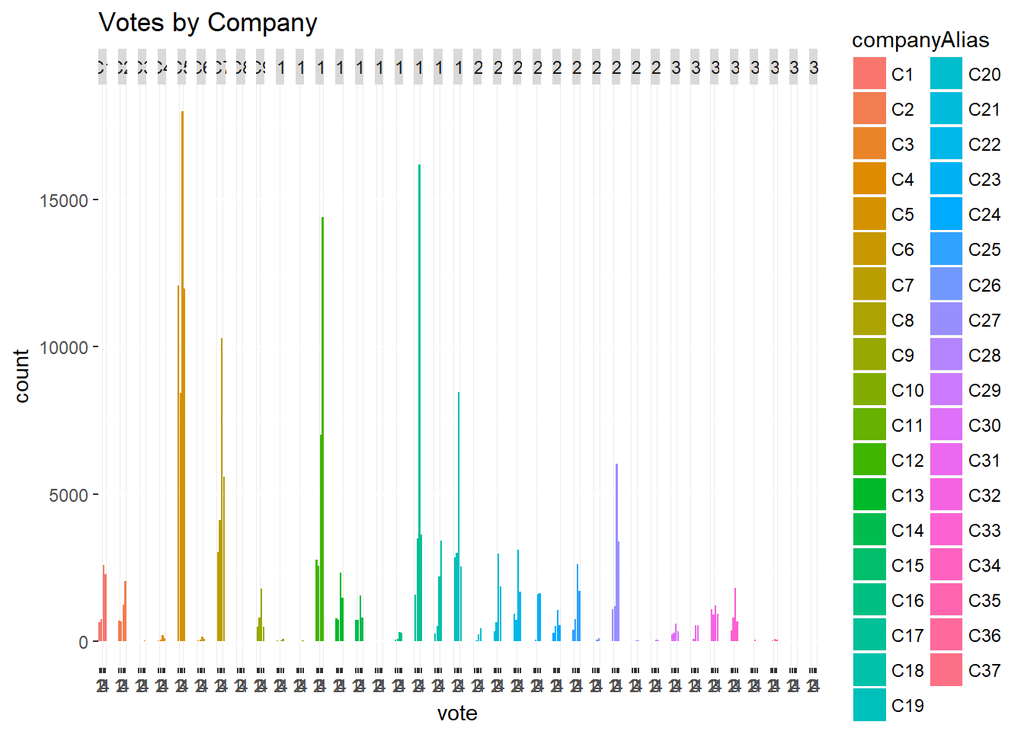

```r
ggplot(votes, aes(vote, fill = companyAlias)) + geom_bar() + facet_grid(~ votes$companyAlias) + labs(title = "Votes by Company")
```

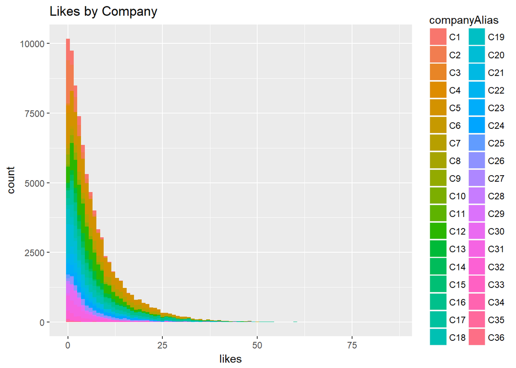

```r
ggplot(comments, aes(likes, fill = companyAlias)) + geom_histogram(binwidth = 1) + labs(title ="Likes by Company")
```

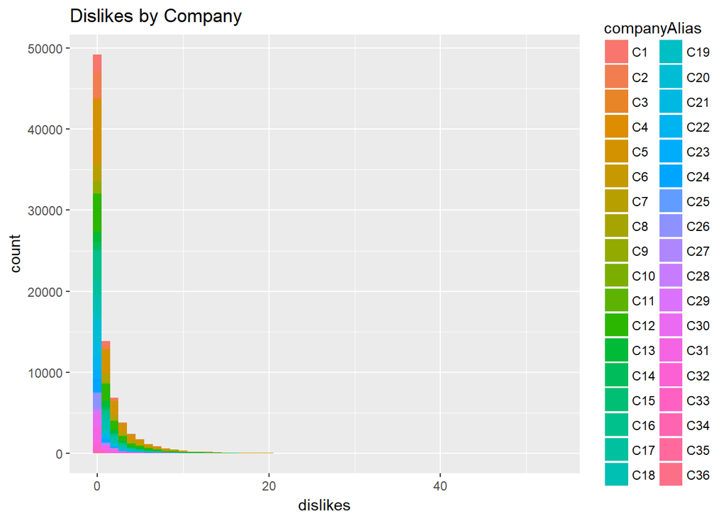

```r
ggplot(comments, aes(dislikes, fill = companyAlias)) + geom_histogram(binwidth = 1) + labs(title = "Dislikes by Company")
```

It was far more common for comments to receive likes than dislikes in every company. These slopes were overall unsurpising.

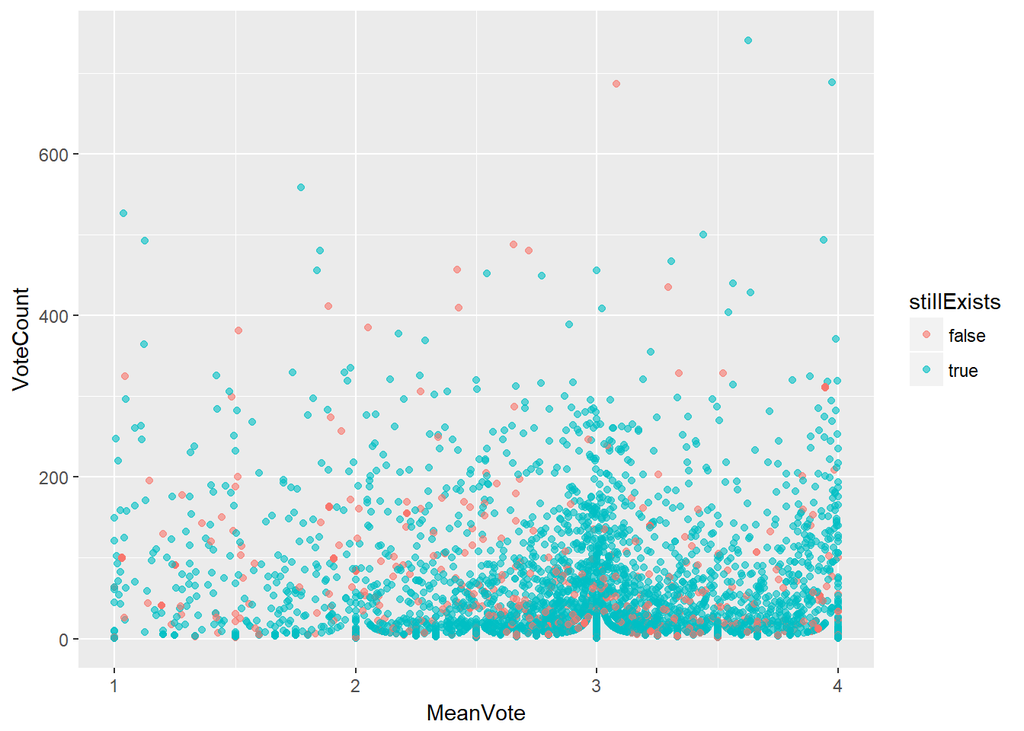

```r
ggplot(EmpCombined, aes(EmpID, col = stillExists, x = MeanVote, y = VoteCount)) + geom_point(position = "jitter", alpha=0.6)
```

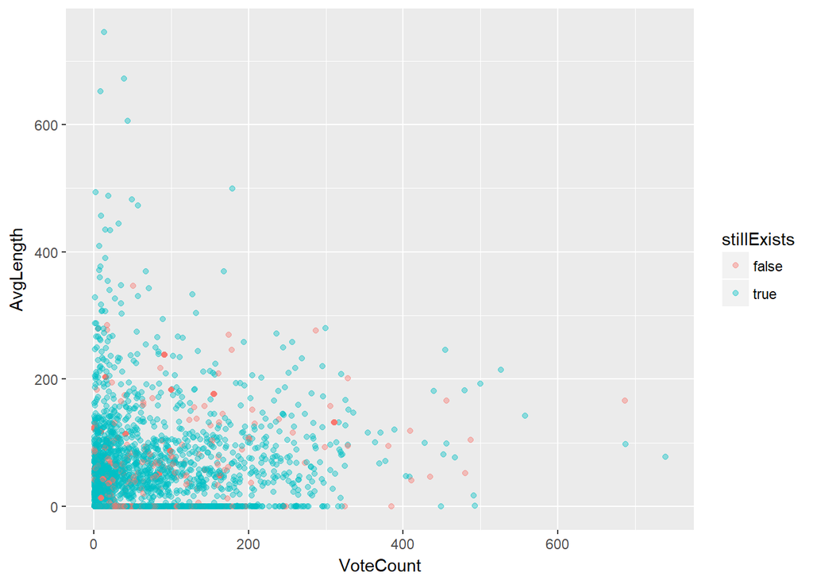

```r
ggplot(EmpCombined, aes(EmpID, col = stillExists, x=VoteCount, y=AvgLength)) + geom_point(position = "jitter", alpha=0.4)
```

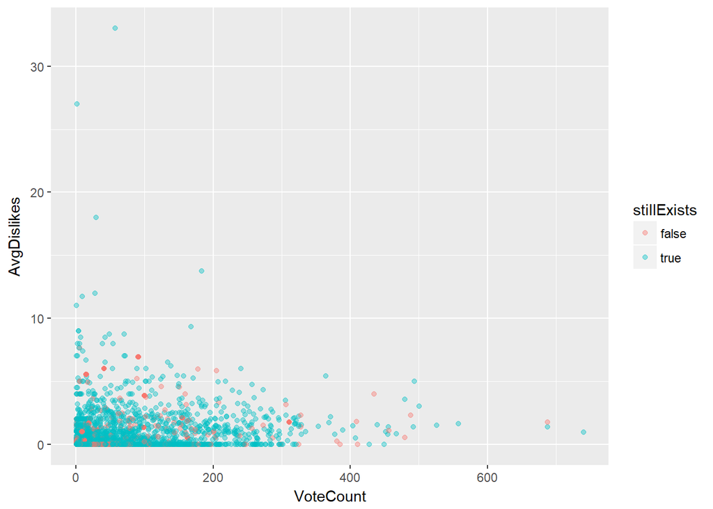

```r
ggplot(EmpCombined, aes(EmpID, col = stillExists, x=VoteCount, y=AvgDislikes)) + geom_point(position = "jitter", alpha=0.4)
```

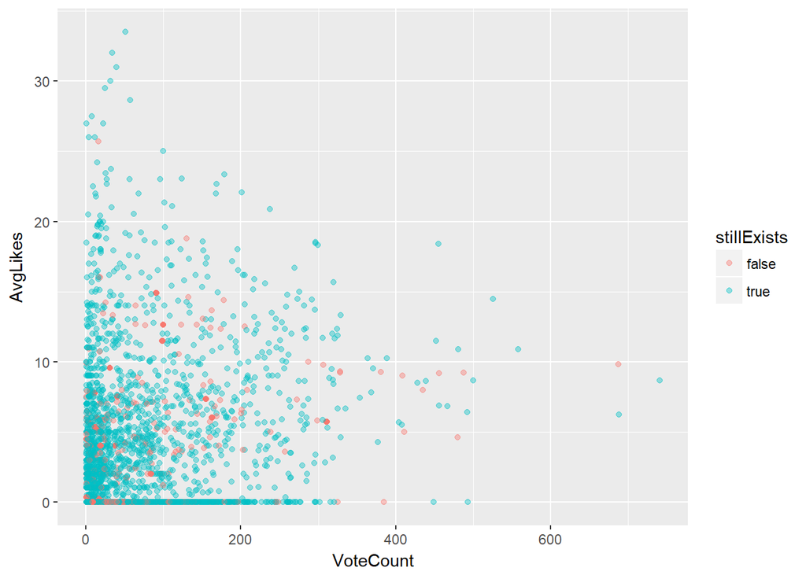

```r
ggplot(EmpCombined, aes(EmpID, col = stillExists, x=VoteCount, y=AvgLikes)) + geom_point(position = "jitter", alpha=0.4)
```

Looking at the average length, average dislikes, and average likes of individuals compared to their vote count, it’s immediately clear that these three elements of engagement were strong indicators of investment in the app, if not the company as well. Interestingly there were few employees that seemed to be engaged by both the votes and also the comments.

## Going Forward

As of now the direction of the work and my expections going into the project are more or less in line. The data was simple enough to clean and examine. It does concern me that after cleaning the data my variables for the upcoming machine learning section aren’t as numerous as I had expected with all these sets. The dates didn’t prove all that impactful for the methods I want to employee with randomforest. If I have issues with this in the future I’ll attempt to go back and find meaning in the dates as a result.